# Homework Assignment 3

Luis Eduardo Acosta Aparicio

### HW 3 - Central Limit Theorem -

- This assignment is based on the illustration of the **Central Limit Theorem (CLT)** presented in our textbook (Crawley, M. J. *“Statistics: An introduction using R”, 2014*).
- You must read pages 70 to 73 of the book in order to produce a similar result.

Consider the ancient game of “craps” described on page 70. It involves the use of two 6-sided dice, and in its simplest form the two dice are thrown and the two scores added together.

- In the book, the example simulates **10,000 plays** of the game. You are required to use a number of simulations equal to **10 times the last 5 digits of your student ID number**.
- Follow the discussion presented in our textbook and produce plots as the ones in page 71 and page 72.
- Make sure to report `mean(mean.score)` and `sd(mean.score)` for your experiment (see page 71). *Comment on your results*.
- Can you think of another game/situation that can be simulated in a similar fashion?

If so, please give a brief description of the game/situation and explain/show how it would confirm the CLT.

```r
# id number
id <- 04381*10
```

```r
score <- 2:12

ways <- c(1,2,3,4,5,6,5,4,3,2,1)

game <- rep(score,ways)

game
```

```
##  [1]  2  3  3  4  4  4  5  5  5  5  6  6  6  6  6  7  7  7  7  7  7  8  8
## [24]  8  8  8  9  9  9  9 10 10 10 11 11 12
```

```r
sample(game,1)
```

```
## [1] 9
```

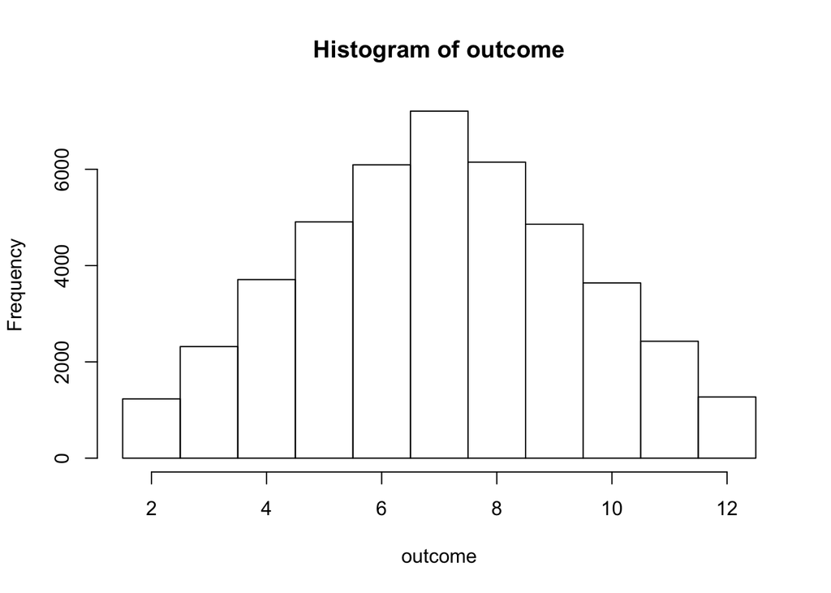

```r
outcome <- numeric(id)
for (i in 1:id)
{
  outcome[i] <- sample(game,1)
}

hist(outcome,breaks=(1.5:12.5))
```

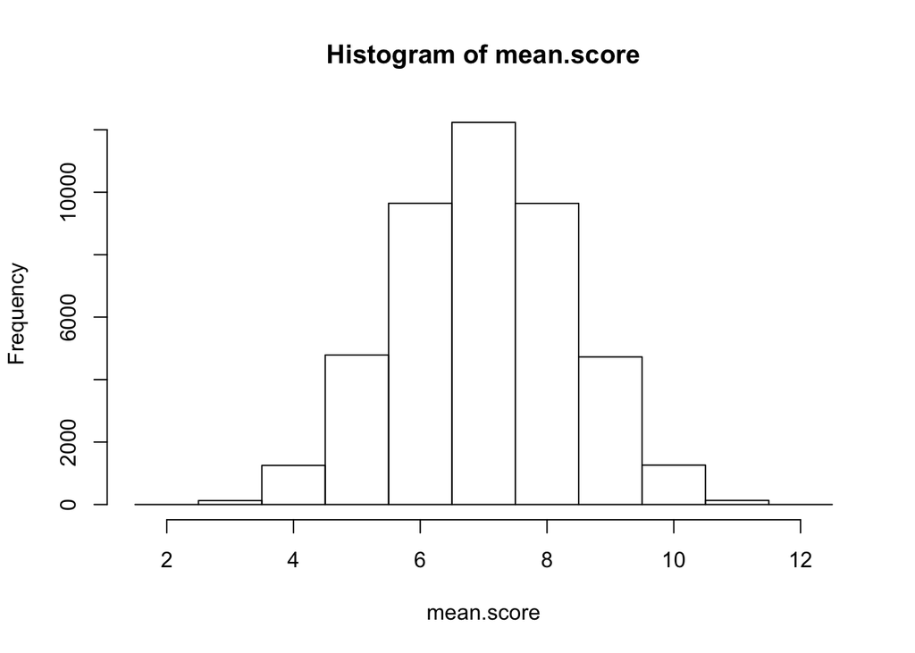

```r
mean.score <- numeric(id)
for (i in 1:id) mean.score[i] <- mean(sample(game,3))
hist(mean.score,breaks=(1.5:12.5))
```

```r
mean(mean.score)
```

```
## [1] 6.998805
```

```r
sd(mean.score)
```

```
## [1] 1.359584
```

The mean and standard deviation are almost the same numbers comparing to books results. It demostrate the central limit theorem

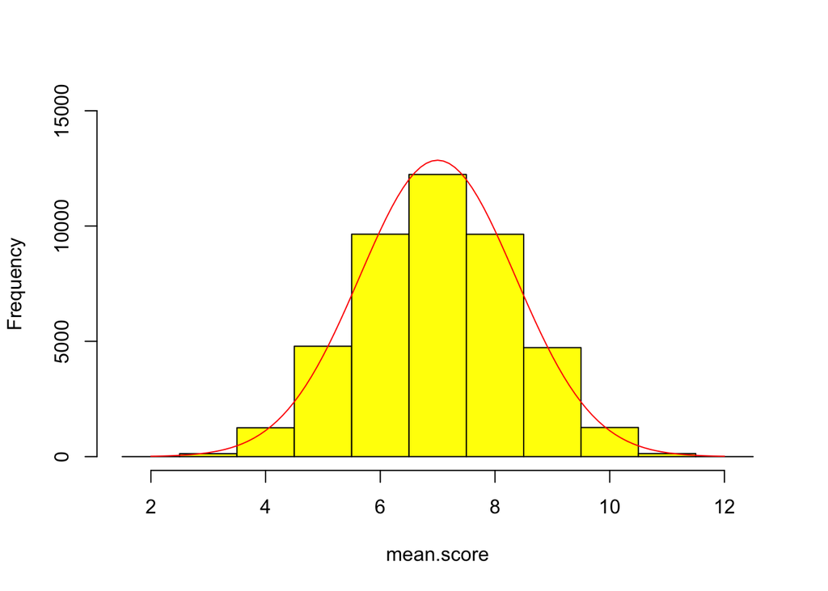

```r
xv <- seq(2,12,0.1)

yv <- id*dnorm(xv,mean(mean.score),sd(mean.score))

hist(mean.score,breaks=(1.5:12.5),ylim=c(0,15000),col="yellow",main="")

lines(xv,yv,col="red")
```

*The coin example was created in conjunction with Gabriella B.

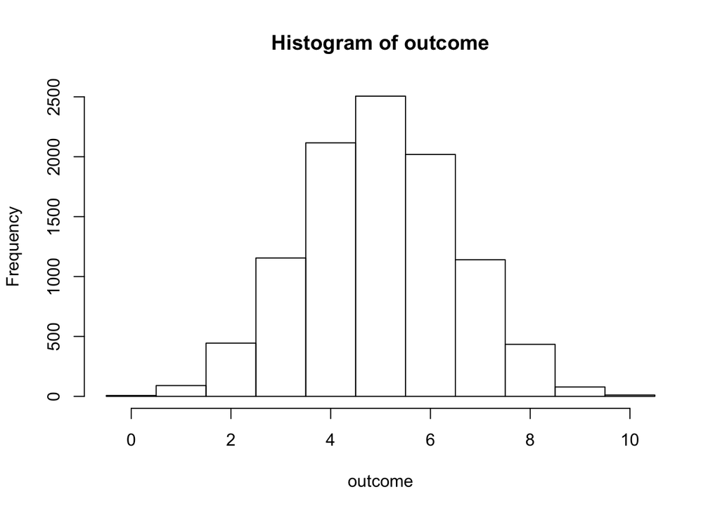

```r
# 0 : tails
# 1 :  heads
# 10000 people throwing the coin 10 times
# sum tails
outcome <- numeric(10000)
for(i in 1:10000) outcome[i] <- sum(sample(0:1,10,rep=T))
hist(outcome, breaks=(-0.5:10.5))
```

```r
mean(outcome)
```

```
## [1] 4.9815
```

```r
sd(outcome)
```

```
## [1] 1.560577
```